# Cancer vs. healthy: detecting copy-number changes

Ido Shalom, Daniel Rodan, Sagi Levin

9 July, 2024

### Libraries used

```r
# Load libraries
library("ggplot2")
library("data.table")
library("tictoc")
library("manipulate")
library(tidyverse)
library(fitdistrplus)
library(dplyr)
library(ggthemes)
library(scales)
library(gridExtra)
library(splines)
library(knitr)
```

### Paths and Data

```r
# Loading file path where the cancer data is stored
load(file = 'data/reads_100_A1.rda')

# Loading file path where the health data is stored
load(file = 'data/reads_100_B1.rda')

# Load the data for GC count
load(file = 'data/GC_100.rda')
```

## Introduction

In this week’s task, we will compare a cancer sample to a healthy sample in order to identify problematic areas on the genome in terms of the number of copies.

Our “end game” is to diagnose whether a specific segment of chromosome 1 is more likely to have cancer.

## Setup - Preliminary part

To make the process easier, we added 0 values to each file to represent 0 reads in a cell or 0 GC count in every cell. This is only for the purpose of ensuring equal cell size along the entire 250M length of the chromosome.

We will eventually clean the data and remove outliers so that the illogical parts (0 GC count in every cell) will not matter.

As requested, we created 100k cells for the cancer sample and healthy sample, each cell containing 2.5k bases, and did the same for the GC content.

```r
# Pad each dataset with zeros to reach 2.5 million elements
desired_length <- 2500000

# Function to pad a vector with zeros
pad_with_zeros <- function(data, desired_length) {
  current_length <- length(data)
  if (current_length < desired_length) {
    data <- c(data, rep(0, desired_length - current_length))
  }
  return(data)
}

# Apply padding to each dataset
GC_100 <- pad_with_zeros(GC_100, desired_length)
reads_100_A1 <- pad_with_zeros(reads_100_A1, desired_length)
reads_100_B1 <- pad_with_zeros(reads_100_B1, desired_length)


# Function to sum every 'n' elements into a new vector
sum_every_n <- function(data, n) {
  new_length <- length(data) %/% n
  new_data <- numeric(new_length)
  for (i in 1:new_length) {
    start_idx <- (i - 1) * n + 1
    end_idx <- i * n
    new_data[i] <- sum(data[start_idx:end_idx])
  }
  return(new_data)
}

# Sum every 25 elements for each dataset
new_GC_100 <- (sum_every_n(GC_100, 25))/25
new_reads_100_A1 <- sum_every_n(reads_100_A1, 25)
new_reads_100_B1 <- sum_every_n(reads_100_B1, 25)
```

Here are our results after removing outliers and fitting the spline regression:

**Note:** We already included the “Median correction” for both cases

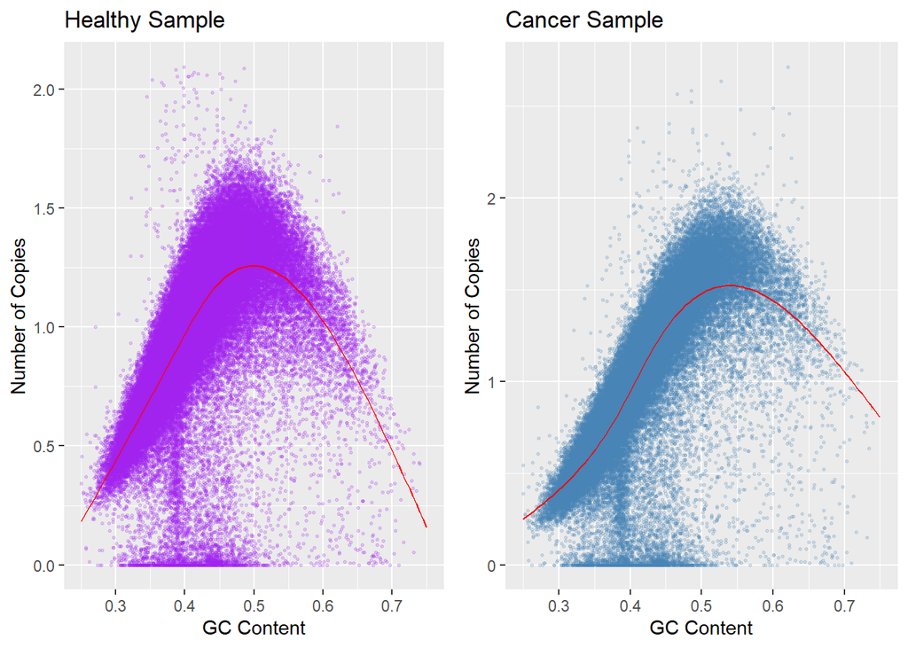

```r
# Create a data frame for the regression model
df <- data.frame(
  cell_index = 1:length(new_reads_100_A1),
  GC_content = new_GC_100,
  reads_cancer = new_reads_100_A1,
  reads_healthy = new_reads_100_B1
)

# filtering criteria
filter_criteria <- function(data, reads_upper, gc_lower, gc_upper) {
  index <- (data$reads_cancer <= reads_upper) &
           (data$reads_healthy <= reads_upper) &
           (data$GC_content >= gc_lower) &
           (data$GC_content <= gc_upper)
  return(data[index, ])
}

# Apply filtering
filtered_df <- filter_criteria(df, reads_upper = 350, gc_lower = 0.25, gc_upper = 0.75)

# Median correction
filtered_df$ai_healthy <- filtered_df$reads_healthy / median(filtered_df$reads_healthy)
filtered_df$ai_cancer <- filtered_df$reads_cancer / median(filtered_df$reads_cancer)

# Fit spline regression models
healthy_spline_model <- lm(ai_healthy ~ ns(GC_content, df = 3), data = filtered_df)
cancer_spline_model <- lm(ai_cancer ~ ns(GC_content, df = 3), data = filtered_df)

# Generate predictions
predicted_gc <- seq(0.25, 0.75, length.out = 100)
predicted_healthy_reads <- predict(healthy_spline_model, newdata = data.frame(GC_content = predicted_gc))
predicted_cancer_reads <- predict(cancer_spline_model, newdata = data.frame(GC_content = predicted_gc))


# plot for healthy sample
p1 <- ggplot() +
  geom_point(aes(x = filtered_df$GC_content, y = filtered_df$ai_healthy), alpha = 0.2, size = 0.5, color = "purple") +
  geom_line(aes(x = predicted_gc, y = predicted_healthy_reads), color = "red") +
  labs(title = "Healthy Sample",
       x = "GC Content",
       y = "Number of Copies") +
  xlim(0.25, 0.75) +
  ylim(0, max(filtered_df$ai_healthy, na.rm = TRUE))

# plot for cancer sample
p2 <- ggplot() +
  geom_point(aes(x = filtered_df$GC_content, y = filtered_df$ai_cancer), alpha = 0.2, size = 0.5, color = "steelblue") +
  geom_line(aes(x = predicted_gc, y = predicted_cancer_reads), color = "red") +
  labs(title = "Cancer Sample",
       x = "GC Content",
       y = "Number of Copies") +
  xlim(0.25, 0.75) +
  ylim(0, max(filtered_df$ai_cancer, na.rm = TRUE))

# Plot side by side
grid.arrange(p1, p2, ncol = 2)
```

## Part A - Variance Composition (For Healthy Sample )

Like we learned in class, we would like to show how the variance of the cells (reads) is divided by the components.

We showed, that we can compute the requested variance by this formula:

$$\text{Var}(Y) = \mathbb{E}(\text{Var}(Y \mid \text{GC})) +
\text{Var}(\mathbb{E}(Y \mid \text{GC})).$$

where:

- $\mathbb{E}(\text{Var}(Y \mid \text{GC}))$ is the variance that we can explain from the Poisson model that we learned.
- $\text{Var}(\mathbb{E}(Y \mid \text{GC}))$ is the variance due to the effect of the GC connection with the reads.

What remains is the “noise” in the variance, which cannot be explained by the two components.

```r
# Variance from the Poisson model
var_Y_GC <- c()
for (gc in seq(0.25, 0.74, 0.01)){
  var_Y_GC <- c(var_Y_GC, filtered_df[(filtered_df$GC_content < (gc+0.01)) & (filtered_df$GC_content >= gc),]$ai_healthy %>% var())
}
Pois_var <- mean(var_Y_GC, na.rm = TRUE)

# Variance due to the effect of the GC
filtered_df$fitted_health <- predict(healthy_spline_model, newdata = filtered_df)

mean_Y_GC <- c()
for (gc in seq(0.25, 0.74, 0.01)){
  mean_Y_GC <- c(mean_Y_GC, abs(filtered_df[(filtered_df$GC_content < (gc+0.01)) & (filtered_df$GC_content >= gc),]$fitted_health %>% mean() - filtered_df[(filtered_df$GC_content < (gc+0.01)) & (filtered_df$GC_content >= gc),]$ai_healthy %>% mean()))
}
GC_var <- var(mean_Y_GC, na.rm = TRUE)

# The inexplicable variance
un_exp_var <- (var(filtered_df$ai_healthy) - Pois_var - GC_var)

# The whole Y variance
total_var <- var(filtered_df$ai_healthy)

# Percentage of Y variance
pois_var_percent <- round((Pois_var / total_var) * 100, 1)
gc_var_percent <- round((GC_var / total_var) * 100, 1)
unexp_var_percent <- round((un_exp_var / total_var) * 100, 1)

# Print results in percentage format
cat("Percentage of variance explained by the Poisson model:", pois_var_percent, "%\n")
```

```
## Percentage of variance explained by the Poisson model: 48.1 %
```

```r
cat("Percentage of variance explained by the effect of GC:", gc_var_percent, "%\n")
```

```
## Percentage of variance explained by the effect of GC: 1.5 %
```

```r
cat("Percentage of unexplained variance:", unexp_var_percent, "%\n")
```

```
## Percentage of unexplained variance: 50.4 %
```

**Results Explanations:**

We can see that most of the variance is not explained at all by the components, probably indicating a low $R^2$.

What’s more surprising is that the part of the variance explained by GC is extremely low compared to what we would expect.

We believe this might have something to do with the median correction that we implemented in advance, but it could also be a mistake on our side.

## Part B - Sample Comparison

### Question 2

For a simple visual comparison, we take the trend curves from before and put them in one plot:

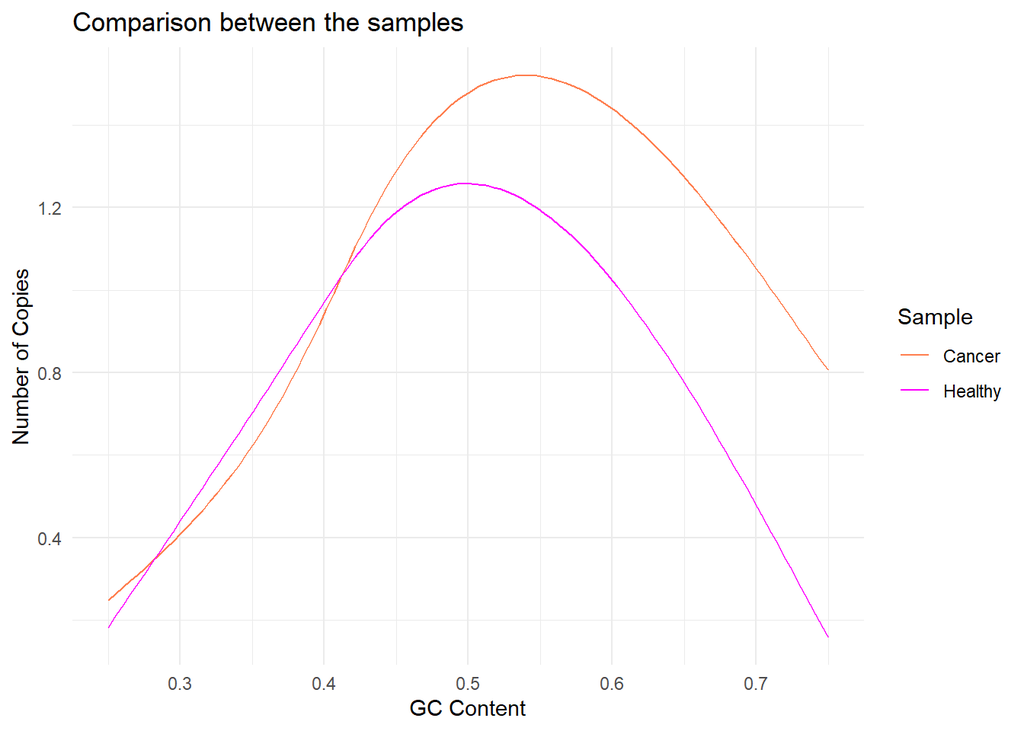

```r
# Combine predictions for visual comparison
combined_df <- data.frame(
  GC_content = rep(predicted_gc, 2),
  Predicted_Reads = c(predicted_healthy_reads, predicted_cancer_reads),
  Sample = rep(c("Healthy", "Cancer"), each = length(predicted_gc))
)

# Create combined plot
ggplot(combined_df, aes(x = GC_content, y = Predicted_Reads, color = Sample)) +
  geom_line() +
  labs(title = "Comparison between the samples",
       x = "GC Content",
       y = "Number of Copies") +
  scale_color_manual(values = c("Healthy" = "magenta", "Cancer" = "coral")) +
  theme_minimal()
```

Then, we wanted to do some quantitative measure comparison, so we took the $R^2$ and the correlation to GC content in both samples:

```r
# R-squared values
r_squared_healthy <- summary(healthy_spline_model)$r.squared
r_squared_cancer <- summary(cancer_spline_model)$r.squared

# Calculate correlation
correlation_healthy <- cor(filtered_df$GC_content, filtered_df$reads_healthy, method = "pearson")
correlation_cancer <- cor(filtered_df$GC_content, filtered_df$reads_cancer, method = "pearson")

# Round to three decimal points
r_squared_healthy <- round(r_squared_healthy, 3)
r_squared_cancer <- round(r_squared_cancer, 3)
correlation_healthy <- round(correlation_healthy, 3)
correlation_cancer <- round(correlation_cancer, 3)

# data frame for the table
comparison_table <- data.frame(
  Metric = c("R-squared", "Correlation"),
  Healthy_Sample = c(r_squared_healthy, correlation_healthy),
  Cancer_Sample = c(r_squared_cancer, correlation_cancer)
)

# Display the table
knitr::kable(comparison_table, caption = "Quantitative measure Comparison")
```

Quantitative measure Comparison

| Metric | Healthy_Sample | Cancer_Sample |
| --- | --- | --- |
| R-squared | 0.498 | 0.659 |
| Correlation | 0.568 | 0.755 |

**Results Explanations:**

- There is a similar relationship between estimates and GC content for both cancer and healthy samples.both samples exhibit a quadratic pattern where estimates increases with GC content up to a certain peak and then decreases.this consistent pattern indicates that GC content has a significant impact on estimates in both types of samples.
- While the general pattern of the relationship between GC content and estimates is the same (quadratic) for both cancer and healthy samples, the connection is not identical. The strength of the relationship, as indicated by the R-squared values, is greater in the cancer sample (0.659) compared to the healthy sample (0.498), suggesting that GC content explains a larger proportion of the variance in estimates in the cancer sample, as we might expect due to its meaning in terms of number of copies.additionally,the correlation between GC content and estimates is stronger in the cancer sample (0.755) than in the healthy sample (0.568), indicating a more robust connection in the cancer sample.

**Note:** It appears that the $R^2$ value we got for the healthy sample is almost a perfect match to the percentage that we got for the two components in part A, so maybe we did something right.

### Question 3

In preparation for the question, we will need to estimate the regression for the requested section.

In our case, the part of the 25-30 million bases actually fit in the 10K place up to the 12K place.

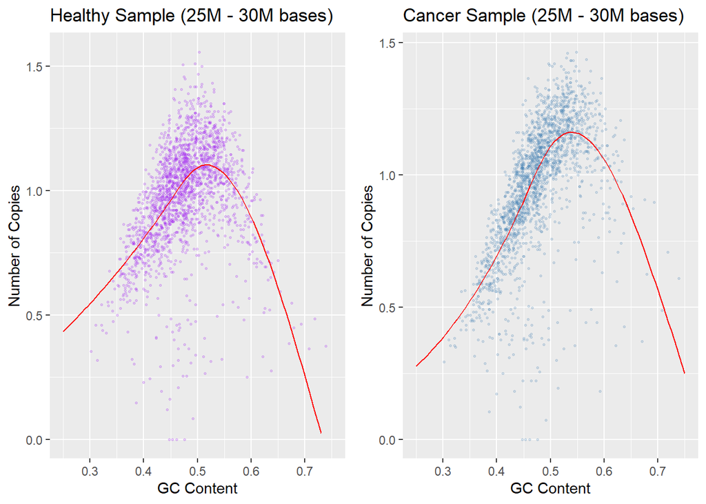

```r
# Cells range for the 25M - 30M bases
cell_range <- 10000:12000

# Filter the data according to above
filtered_segment <- df[cell_range, ]

# Median correction
filtered_segment$ai_healthy <- filtered_segment$reads_healthy / median(filtered_segment$reads_healthy)
filtered_segment$ai_cancer <- filtered_segment$reads_cancer / median(filtered_segment$reads_cancer)

# Fit spline regression models
healthy_spline_segment <- lm(ai_healthy ~ ns(GC_content, df = 3), data = filtered_segment)
cancer_spline_segment <- lm(ai_cancer ~ ns(GC_content, df = 3), data = filtered_segment)

# Generate predictions
predicted_gc_segment <- seq(0.25, 0.75, length.out = 100)
predicted_healthy_reads_segment <- predict(healthy_spline_segment, newdata = data.frame(GC_content = predicted_gc_segment))
predicted_cancer_reads_segment <- predict(cancer_spline_segment, newdata = data.frame(GC_content = predicted_gc_segment))

# plot for healthy sample
p1_segment <- ggplot() +
  geom_point(aes(x = filtered_segment$GC_content, y = filtered_segment$ai_healthy), alpha = 0.2, size = 0.5, color = "purple") +
  geom_line(aes(x = predicted_gc_segment, y = predicted_healthy_reads_segment), color = "red") +
  labs(title = "Healthy Sample (25M - 30M bases)",
       x = "GC Content",
       y = "Number of Copies") +
  xlim(0.25, 0.75) +
  ylim(0, max(filtered_segment$ai_healthy, na.rm = TRUE))

# plot for cancer sample
p2_segment <- ggplot() +
  geom_point(aes(x = filtered_segment$GC_content, y = filtered_segment$ai_cancer), alpha = 0.2, size = 0.5, color = "steelblue") +
  geom_line(aes(x = predicted_gc_segment, y = predicted_cancer_reads_segment), color = "red") +
  labs(title = "Cancer Sample (25M - 30M bases)",
       x = "GC Content",
       y = "Number of Copies") +
  xlim(0.25, 0.75) +
  ylim(0, max(filtered_segment$ai_cancer, na.rm = TRUE))

# Plot side by side
grid.arrange(p1_segment, p2_segment, ncol = 2)
```

#### Section A

We began with the estimation of the number of copies for both samples.

In our case, we already did the median correction, so we will just compute their means:

```r
# Calculate the number of copies
number_copies_healthy <- mean(filtered_segment$ai_healthy)
number_copies_cancer <- mean(filtered_segment$ai_cancer)

# Display the results
cat("Estimated number of copies - healthy sample (25M - 30M bases):", round(number_copies_healthy, 3), "\n")
```

```
## Estimated number of copies - healthy sample (25M - 30M bases): 0.967
```

```r
cat("Estimated number of copies - cancer sample (25M - 30M bases):", round(number_copies_cancer, 3), "\n")
```

```
## Estimated number of copies - cancer sample (25M - 30M bases): 0.951
```

**Results Explanations:**

First, we can see that both samples are close to 1 as we expected.

From this simple result, we might conclude that the nature of a cancer sample is to have a shortage in the number of copies.

We learn that what “builds” the assumption of 1 copy is that there are 2 genomic helices that complement each other from opposite directions, and when we get the value 1 for the estimator, it means that there are 2 such helices.

The cancerous sample may show us that there is a tendency to find only one helix in a cancerous cell, and perhaps this is the problematic mutation.

Now, we will see what the connection is between the estimated number of copies and the location on the chromosome:

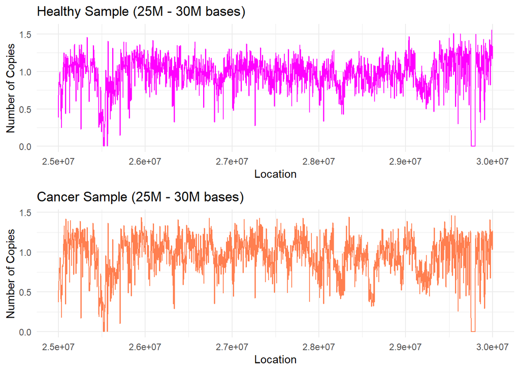

```r
# Add a location column
filtered_segment$location <- seq(25e6, 30e6, length.out = length(cell_range))

# plot for healthy sample in the specific segment
p1_segment <- ggplot() +
  geom_line(aes(x = filtered_segment$location, y = filtered_segment$ai_healthy), color = "magenta") +
  labs(title = "Healthy Sample (25M - 30M bases)",
       x = "Location",
       y = "Number of Copies") +
  theme_minimal()

# plot for cancer sample in the specific segment
p2_segment <- ggplot() +
  geom_line(aes(x = filtered_segment$location, y = filtered_segment$ai_cancer), color = "coral") +
  labs(title = "Cancer Sample (25M - 30M bases)",
       x = "Location",
       y = "Number of Copies") +
  theme_minimal()

# Plot one above the other
grid.arrange(p1_segment, p2_segment, ncol = 1)
```

**Results Explanations:**

At first glance, it seems that the patterns show pretty much the same trends in both samples, but with small changes.

One notable difference is around the 28.5M area, where the cancer sample shows a major drop to 0.5 in the number of copies, in contrast to the healthy sample, which stays around the value of 1.

We will continue to investigate this point in section B & C.

We also did a small comparison between the estimate for the number of copies with median correction only to the estimate for the number of copies with median correction and GC effect:

```r
# median correction  in the specific segment
filtered_segment$ai_healthy <- filtered_segment$reads_healthy / median(filtered_segment$reads_healthy)
filtered_segment$ai_cancer <- filtered_segment$reads_cancer / median(filtered_segment$reads_cancer)

# Calculate the number of copies with median correction only
number_of_copies_healthy_median <- mean(filtered_segment$ai_healthy)
number_of_copies_cancer_median <- mean(filtered_segment$ai_cancer)

# Fit spline regression models in the specific segment
healthy_spline_segment <- lm(reads_healthy ~ ns(GC_content, df = 3), data = filtered_segment)
cancer_spline_segment <- lm(reads_cancer ~ ns(GC_content, df = 3), data = filtered_segment)

# Generate predictions
predicted_gc_segment <- seq(0, 1, length.out = 100)
predicted_healthy_reads_segment <- predict(healthy_spline_segment, newdata = data.frame(GC_content = predicted_gc_segment))
predicted_cancer_reads_segment <- predict(cancer_spline_segment, newdata = data.frame(GC_content = predicted_gc_segment))

# Calculate the number of copies with median correction and GC effect
number_of_copies_healthy_gc <- mean(predicted_healthy_reads_segment/median(predicted_healthy_reads_segment))
number_of_copies_cancer_gc <- mean(predicted_cancer_reads_segment/median(predicted_cancer_reads_segment))

# Round to three decimal points
number_of_copies_healthy_median <- round(number_of_copies_healthy_median, 3)
number_of_copies_cancer_median <- round(number_of_copies_cancer_median, 3)
number_of_copies_healthy_gc <- round(number_of_copies_healthy_gc, 3)
number_of_copies_cancer_gc <- round(number_of_copies_cancer_gc, 3)

# Create a data frame to display the results
comparison_table <- data.frame(
  Sample = c("Healthy", "Cancer"),
  Median_Correction_Only = c(number_of_copies_healthy_median, number_of_copies_cancer_median),
  Median_Correction_and_GC_Effect = c(number_of_copies_healthy_gc, number_of_copies_cancer_gc)
)

# Display the table
knitr::kable(comparison_table, caption = "Number of Copies Estimate")
```

Number of Copies Estimate

| Sample | Median_Correction_Only | Median_Correction_and_GC_Effect |
| --- | --- | --- |
| Healthy | 0.967 | 0.376 |
| Cancer | 0.951 | 0.981 |

**Results Explanations:**

- For the healthy sample, using the GC-based correction is very important. When we only use the median correction, the estimated number of copies is about 0.967, which is close to the expected number for a healthy sample. However, when we factor in the GC content, the estimate drops to 0.376. This big difference suggests that the initial estimate was too high because it didn’t account for how the GC content affects the read coverage.

**Note:** We believe that the “median correction with GC effect” number might be too low.

- For the cancer sample, the GC-based correction doesn’t make as much of a difference. The estimated number of copies is 0.951 with just the median correction, and it slightly increases to 0.981 when we add the GC content. This small change indicates that GC content doesn’t significantly impact the read coverage in the cancer sample. Therefore, this suggests that other factors might be influencing the read coverage in the cancer sample more than GC content.

#### Section B

Now, we will continue our investigation into the connection between the estimated number of copies and the location on the chromosome.

We will begin with the cancer sample and try to locate cell sequences in which a change in the number of copies is possible.

We chose to define a possible change in the number of copies in a way that is relevant to our purpose.

If we get a cell with a value of 0.5, we mark it with a dashed vertical blue line, and if we get a cell with a value of 1.5, we mark it with a dashed vertical green line.

Also, we wanted to located their cell index so we printed that as well:

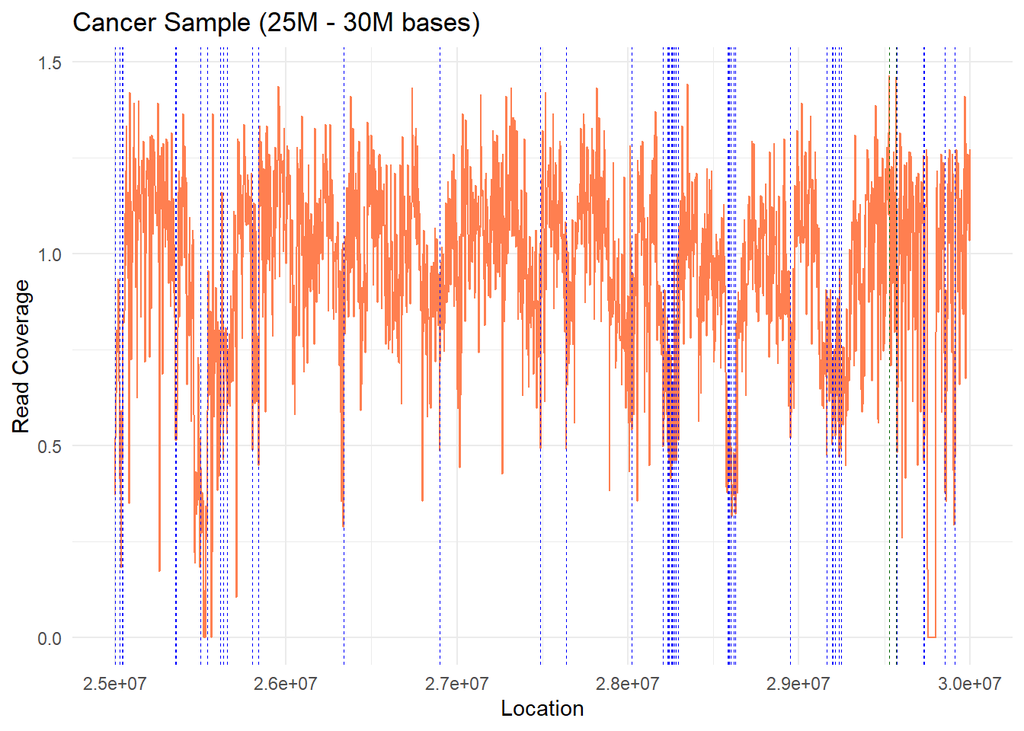

```r
# Identify specific estimation values
locations_0_5 <- filtered_segment$cell_index[abs(filtered_segment$ai_cancer - 0.5) < 0.05]
locations_1_5 <- filtered_segment$cell_index[abs(filtered_segment$ai_cancer - 1.5) < 0.05]

# Function to format consecutive locations
format_consecutive <- function(locations) {
  locations <- sort(locations)
  if (length(locations) == 0) return(character(0))
  consecutive_ranges <- c()
  start <- locations[1]
  end <- locations[1]
  for (i in 2:length(locations)) {
    if (locations[i] == end + 1) {
      end <- locations[i]
    } else {
      if (start == end) {
        consecutive_ranges <- c(consecutive_ranges, as.character(start))
      } else {
        consecutive_ranges <- c(consecutive_ranges, paste(start, "-", end))
      }
      start <- locations[i]
      end <- locations[i]
    }
  }
  if (start == end) {
    consecutive_ranges <- c(consecutive_ranges, as.character(start))
  } else {
    consecutive_ranges <- c(consecutive_ranges, paste(start, "-", end))
  }
  return(consecutive_ranges)
}

# Format consecutive locations
formatted_locations_0_5 <- format_consecutive(locations_0_5)
formatted_locations_1_5 <- format_consecutive(locations_1_5)

# plot for cancer sample
p_cancer <- ggplot() +
  geom_line(aes(x = filtered_segment$location, y = filtered_segment$ai_cancer), color = "coral") +
  geom_vline(xintercept = filtered_segment$location[filtered_segment$cell_index %in% locations_0_5], color = "blue", linetype = "dashed", size = 0.3) +
  geom_vline(xintercept = filtered_segment$location[filtered_segment$cell_index %in% locations_1_5], color = "darkgreen", linetype = "dashed", size = 0.3) +
  labs(title = "Cancer Sample (25M - 30M bases) ",
       x = "Location",
       y = "Read Coverage") +
  theme_minimal()

# Display the plot
print(p_cancer)
```

```r
# Function to print locations nicely
print_nicely <- function(locations, title) {
  cat(title, "\n\n")
  for (i in seq_along(locations)) {
    cat(locations[i])
    if (i %% 5 == 0 || i == length(locations)) {
      cat("\n")
    } else {
      cat(", ")
    }
  }
  cat("\n")
}

# Display locations
print_nicely(formatted_locations_0_5, "Cell locations with estimate ~0.5:")
```

```
## Cell locations with estimate ~0.5:
##
## 10001, 10011, 10017 - 10018, 10142, 10144
## 10200, 10216, 10246, 10253, 10262
## 10322, 10335, 10535, 10759, 10996
## 11055, 11209, 11282, 11293 - 11294, 11296
## 11302, 11304 - 11305, 11309, 11313, 11318
## 11433, 11435 - 11437, 11440 - 11441, 11448, 11451
## 11580, 11665, 11677, 11679, 11685
## 11693 - 11694, 11699, 11830, 11892, 11894
## 11941, 11965
```

```r
print_nicely(formatted_locations_1_5, "Cell locations with estimate ~1.5:")
```

```
## Cell locations with estimate ~1.5:
##
## 11811, 11827
```

#### Section C

Let’s implement the same idea from Section B to our healthy sample in order to catch some meaningful differences:

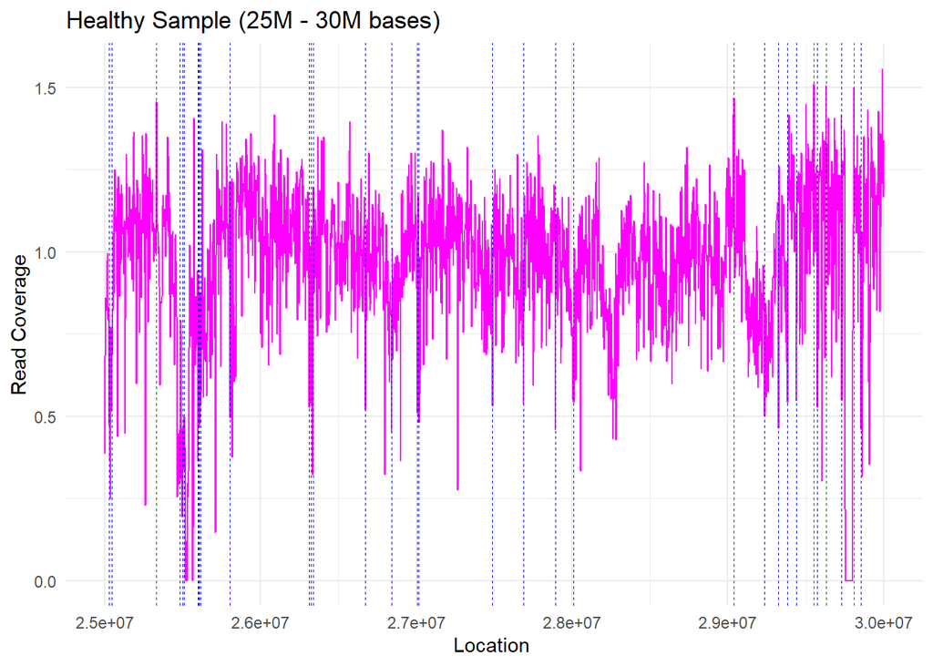

```r
# Identify specific estimation values
locations_0_5_healthy <- filtered_segment$cell_index[abs(filtered_segment$ai_healthy - 0.5) < 0.05]
locations_1_5_healthy <- filtered_segment$cell_index[abs(filtered_segment$ai_healthy - 1.5) < 0.05]

# Function to format consecutive locations
format_consecutive <- function(locations) {
  locations <- sort(locations)
  if (length(locations) == 0) return(character(0))
  consecutive_ranges <- c()
  start <- locations[1]
  end <- locations[1]
  for (i in 2:length(locations)) {
    if (locations[i] == end + 1) {
      end <- locations[i]
    } else {
      if (start == end) {
        consecutive_ranges <- c(consecutive_ranges, as.character(start))
      } else {
        consecutive_ranges <- c(consecutive_ranges, paste(start, "-", end))
      }
      start <- locations[i]
      end <- locations[i]
    }
  }
  if (start == end) {
    consecutive_ranges <- c(consecutive_ranges, as.character(start))
  } else {
    consecutive_ranges <- c(consecutive_ranges, paste(start, "-", end))
  }
  return(consecutive_ranges)
}

# Format consecutive locations
formatted_locations_0_5_healthy <- format_consecutive(locations_0_5_healthy)
formatted_locations_1_5_healthy <- format_consecutive(locations_1_5_healthy)

# plot for healthy sample
p_healthy <- ggplot() +
  geom_line(aes(x = filtered_segment$location, y = filtered_segment$ai_healthy), color = "magenta") +
  geom_vline(xintercept = filtered_segment$location[filtered_segment$cell_index %in% locations_0_5_healthy], color = "blue", linetype = "dashed", size = 0.3) +
  geom_vline(xintercept = filtered_segment$location[filtered_segment$cell_index %in% locations_1_5_healthy], color = "darkgreen", linetype = "dashed", size = 0.3) +
  labs(title = "Healthy Sample (25M - 30M bases)",
       x = "Location ",
       y = "Read Coverage") +
  theme_minimal()

# Display the plot
print(p_healthy)
```

```r
# Function to print locations nicely
print_nicely <- function(locations, title) {
  cat(title, "\n\n")
  for (i in seq_along(locations)) {
    cat(locations[i])
    if (i %% 5 == 0 || i == length(locations)) {
      cat("\n")
    } else {
      cat(", ")
    }
  }
  cat("\n")
}

# Display locations
print_nicely(formatted_locations_0_5_healthy, "Cell locations with estimate ~0.5 (Healthy):")
```

```
## Cell locations with estimate ~0.5 (Healthy):
##
## 10012, 10018, 10193, 10200, 10204
## 10240, 10242 - 10243, 10246, 10322, 10525
## 10530, 10535, 10669, 10736, 10802
## 10807, 10996, 11075, 11157, 11204
## 11694, 11729 - 11730, 11753, 11775, 11830
## 11892, 11942
```

```r
print_nicely(formatted_locations_1_5_healthy, "Cell locations with estimate ~1.5 (Healthy):")
```

```
## Cell locations with estimate ~1.5 (Healthy):
##
## 10133, 11616, 11821, 11852, 11923
```

```r
# Identify specific values for cancer sample
locations_0_5_cancer <- filtered_segment$cell_index[abs(filtered_segment$ai_cancer - 0.5) < 0.05]
locations_1_5_cancer <- filtered_segment$cell_index[abs(filtered_segment$ai_cancer - 1.5) < 0.05]

# Identify specific values for healthy sample
locations_0_5_healthy <- filtered_segment$cell_index[abs(filtered_segment$ai_healthy - 0.5) < 0.05]
locations_1_5_healthy <- filtered_segment$cell_index[abs(filtered_segment$ai_healthy - 1.5) < 0.05]

# Combine locations for each sample
locations_cancer <- c(locations_0_5_cancer, locations_1_5_cancer)
locations_healthy <- c(locations_0_5_healthy, locations_1_5_healthy)

# Find intersections and differences
common_cells <- intersect(locations_cancer, locations_healthy)
different_cells <- union(setdiff(locations_cancer, locations_healthy), setdiff(locations_healthy, locations_cancer))

# Function to print a list of locations
print_nice_list <- function(locations, title) {
  cat(title, "\n")
  if (length(locations) == 0) {
    cat("None\n")
  } else {
    for (i in seq_along(locations)) {
      cat(locations[i])
      if (i %% 5 == 0 || i == length(locations)) {
        cat("\n")
      } else {
        cat(", ")
      }
    }
  }
  cat("\n")
}

# Print common and different cells
print_nice_list(common_cells, "Cells that are the same between samples:")
```

```
## Cells that are the same between samples:
## 10018, 10200, 10246, 10322, 10535
## 10996, 11694, 11830, 11892
```

```r
print_nice_list(different_cells, "Cells that are different between samples:")
```

```
## Cells that are different between samples:
## 10001, 10011, 10017, 10142, 10144
## 10216, 10253, 10262, 10335, 10759
## 11055, 11209, 11282, 11293, 11294
## 11296, 11302, 11304, 11305, 11309
## 11313, 11318, 11433, 11435, 11436
## 11437, 11440, 11441, 11448, 11451
## 11580, 11665, 11677, 11679, 11685
## 11693, 11699, 11894, 11941, 11965
## 11811, 11827, 10012, 10193, 10204
## 10240, 10242, 10243, 10525, 10530
## 10669, 10736, 10802, 10807, 11075
## 11157, 11204, 11729, 11730, 11753
## 11775, 11942, 10133, 11616, 11821
## 11852, 11923
```

```r
# Define the range intervals
ranges <- list(
  "10000 - 10250" = 10000:10250,
  "10250 - 10500" = 10251:10500,
  "10500 - 10750" = 10501:10750,
  "10750 - 11000" = 10751:11000,
  "11000 - 11250" = 11001:11250,
  "11250 - 11500" = 11251:11500,
  "11500 - 11750" = 11501:11750,
  "11750 - 12000" = 11751:12000
)

# Function to categorize cells into ranges
categorize_cells <- function(cells, ranges) {
  categorized_cells <- list()
  for (range_name in names(ranges)) {
    categorized_cells[[range_name]] <- cells[cells %in% ranges[[range_name]]]
  }
  return(categorized_cells)
}

# Categorize the different cells
categorized_cells <- categorize_cells(different_cells, ranges)

# Print the cells
for (range_name in names(categorized_cells)) {
  cat(range_name, ":\n", paste(categorized_cells[[range_name]], collapse = ", "), "\n\n")
}
```

```
## 10000 - 10250 :
##  10001, 10011, 10017, 10142, 10144, 10216, 10012, 10193, 10204, 10240, 10242, 10243, 10133
##
## 10250 - 10500 :
##  10253, 10262, 10335
##
## 10500 - 10750 :
##  10525, 10530, 10669, 10736
##
## 10750 - 11000 :
##  10759, 10802, 10807
##
## 11000 - 11250 :
##  11055, 11209, 11075, 11157, 11204
##
## 11250 - 11500 :
##  11282, 11293, 11294, 11296, 11302, 11304, 11305, 11309, 11313, 11318, 11433, 11435, 11436, 11437, 11440, 11441, 11448, 11451
##
## 11500 - 11750 :
##  11580, 11665, 11677, 11679, 11685, 11693, 11699, 11729, 11730, 11616
##
## 11750 - 12000 :
##  11894, 11941, 11965, 11811, 11827, 11753, 11775, 11942, 11821, 11852, 11923
```

**Results Explanations:**

So, we can see there are many cells that are considered different in terms of the estimation of the number of copies between the samples.

We can see that mostly at the end of the segment of bases we chose, there are differences in the number of copies between the samples, and most of these are marked in blue, which strengthens our assumption from Section A.

It seems that at the end of the segment, there is a missing helix in the cancer sample!

#### Section D

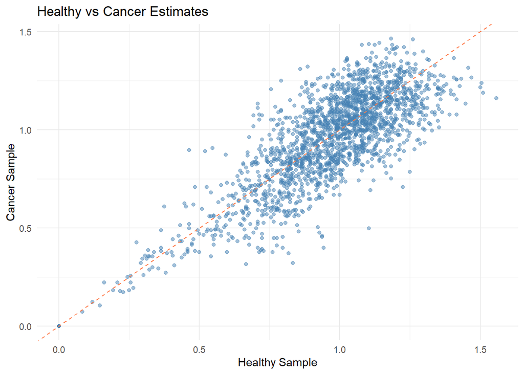

```r
# Create a data frame for the scatter plot
scatter_data <- data.frame(
  Cell_Index = filtered_segment$cell_index,
  Healthy_Copies = filtered_segment$ai_healthy,
  Cancer_Copies = filtered_segment$ai_cancer
)

# Create scatter plot with 45-degree line
scatter_plot <- ggplot(scatter_data, aes(x = Healthy_Copies, y = Cancer_Copies)) +
  geom_point(alpha = 0.5, color = "steelblue") +
  labs(title = "Healthy vs Cancer Estimates",
       x = "Healthy Sample",
       y = "Cancer Sample") +
  theme_minimal() +
  geom_abline(slope = 1, intercept = 0, linetype = "dashed", color = "coral")

# Display the plot
print(scatter_plot)
```

**Results Explanations:**

What we are seeing is not surprising in any way. The orange line marks what we would expect in a perfect world with two healthy cells and no differences in the number of copies.

Of course, we observe a lot more variety from this line.

- We can think of a relative visual estimate to the problem of different numbers of copies as the distance that a specific cell is found from this line. the larger the distance gets, the more we could become suspicious about the nature of this cell and whether it is the main cause of the cancer.

## Short summary

If we are right with our analysis, it seems that problematic areas, until the very end, are mostly marked as missing helix, which is connected to the cancer sample.

This is a pretty strong statement, so we need to remember that we could be mistaken and that there are many elements (including the unexplained variance) that could alter the nature of our results.